# NYC Taxi Cab Data Analysis

## CMSC 320 Final: Tyler Liberto and Josh Zbozny

## Part 1: Introduction

Taxis are and have always been a useful and efficient way to get around in big cities such as New York City. With recent events such as the COVID-19 pendemic and the rise of businesses like Uber, taxi drivers have taken a bit of a hit. However, they are still operating at a very high level, with tens of thousands of rides each day. Because of this, we wanted to look into some of this data to see exactly how and when people are using taxis, and maybe look into why as well.

Our dataset comes straight from nyc.gov (https://www1.nyc.gov/site/tlc/about/tlc-trip-record-data.page). While they have data for every month dating back to 2009, we just used the most recent month on record, which was Febraury 2022. Just days before submitting, the website changed the way you can download the data from CSV to Parquet, so while we used the CSV that we had downloaded when we started, to replicate our data, you would have to read it as a parquet instead, which is not much of a difference.

While there was no specific question we were hoping to answer, we wanted to look at all of the data provided to us and see what different types of analysis we could do in order to answer a variety of questions. So, if you are new to data science with Python, this project should help you learn many different aspects of analyzing data.

For this project, the following libraries will be required:

```
- pandas
- matplotlib.pyplot
- numpy
- scipy.stats
- random
- statistics
```

## Part 2: Data Gathering/Tidying/Processing

Now that we have introduced the project, we can begin gathering and processing the data. The dataset that we used was generally very clean. Most rows were filled in fully, there were no mixed types for us to worry about, and the data was organized very nicely. This greatly reduced the amount of tidying and processing that was needed, though in a dataset this large, there were still some things that needed to be fixed.

```python
import pandas as pd
import matplotlib.pyplot as plt
import numpy as np
import scipy.stats as sp
import random
import statistics as s
```

Since we got the data as a CSV, importing as a DataFrame is easy. Remember that a DataFrame is basically just a table, so it can store data in a row/column format to make entries easily accessible. As we mentioned before, the data is no longer accessible as a CSV, so you would need to use *pd.read_parquet()* instead of *pd.read_csv()* like we did below.

```python
taxis = pd.read_csv('yellow_tripdata_2022-02.csv', dtype={'store_and_fwd_flag':'str'})
taxis.head()
```

|  | VendorID | tpep_pickup_datetime | tpep_dropoff_datetime | passenger_count | trip_distance | RatecodeID | store_and_fwd_flag | PULocationID | DOLocationID | payment_type | fare_amount | extra | mta_tax | tip_amount | tolls_amount | improvement_surcharge | total_amount | congestion_surcharge |
| --- | --- | --- | --- | --- | --- | --- | --- | --- | --- | --- | --- | --- | --- | --- | --- | --- | --- | --- |
| 0 | 1 | 2022-02-01 00:06:58 | 2022-02-01 00:19:24 | 1.0 | 5.40 | 1.0 | N | 138 | 252 | 1 | 17.0 | 1.75 | 0.5 | 3.90 | 0.00 | 0.3 | 23.45 | 0.0 |
| 1 | 1 | 2022-02-01 00:38:22 | 2022-02-01 00:55:55 | 1.0 | 6.40 | 1.0 | N | 138 | 41 | 2 | 21.0 | 1.75 | 0.5 | 0.00 | 6.55 | 0.3 | 30.10 | 0.0 |
| 2 | 1 | 2022-02-01 00:03:20 | 2022-02-01 00:26:59 | 1.0 | 12.50 | 1.0 | N | 138 | 200 | 2 | 35.5 | 1.75 | 0.5 | 0.00 | 6.55 | 0.3 | 44.60 | 0.0 |
| 3 | 2 | 2022-02-01 00:08:00 | 2022-02-01 00:28:05 | 1.0 | 9.88 | 1.0 | N | 239 | 200 | 2 | 28.0 | 0.50 | 0.5 | 0.00 | 3.00 | 0.3 | 34.80 | 2.5 |
| 4 | 2 | 2022-02-01 00:06:48 | 2022-02-01 00:33:07 | 1.0 | 12.16 | 1.0 | N | 138 | 125 | 1 | 35.5 | 0.50 | 0.5 | 8.11 | 0.00 | 0.3 | 48.66 | 2.5 |

Now that we have the data, we can look through the DataFrame to see what we need and what we don't need. The first thing we saw when looking through was that there was some numbers that just did not make sense, along with some that were missing all together. For example, the columns *trip_distance* and *fare_amount* had some negative entries, which does not make sense considering the context of the data. Because this dataset contains millions of entries, we can afford to just remove all nonsensical or missing data to make the analysis easier. There is also a RatecodeID column, where different numbers represent different kind of taxi rides. We are only concerned with the standard rides, so we can limit that and drop that column as well. For our graphical and statistical analysis later, we need to calculate the total amount spent per ride on just the taxi ride, excluding the tip. This is different than the fare_amount column, as we also want to include the price of any extra fees, taxes, tolls, or surcharges

```python
# Removing bad/missing data
taxis_cut = taxis.dropna()
taxis_cut = taxis_cut[taxis_cut['RatecodeID'] == 1.0]
taxis_cut = taxis_cut[taxis_cut['trip_distance'] > 0]
taxis_cut = taxis_cut[taxis_cut['fare_amount'] > 0]
taxis_cut = taxis_cut[taxis_cut['extra'] >= 0]
taxis_cut = taxis_cut[taxis_cut['mta_tax'] >= 0]
taxis_cut = taxis_cut[taxis_cut['tolls_amount'] >= 0]
taxis_cut = taxis_cut[taxis_cut['improvement_surcharge'] >= 0]
taxis_cut = taxis_cut[taxis_cut['total_amount'] > 0]

# Deleting unneccesary columns
taxis_cut = taxis_cut.drop(columns=['store_and_fwd_flag', 'VendorID', 'RatecodeID'])
taxis_cut = taxis_cut.reset_index()

taxis_cut['total_charge'] = taxis_cut['total_amount'] - taxis_cut['tip_amount']



taxis_cut.head(5)
```

|  | index | tpep_pickup_datetime | tpep_dropoff_datetime | passenger_count | trip_distance | PULocationID | DOLocationID | payment_type | fare_amount | extra | mta_tax | tip_amount | tolls_amount | improvement_surcharge | total_amount | congestion_surcharge | total_charge |
| --- | --- | --- | --- | --- | --- | --- | --- | --- | --- | --- | --- | --- | --- | --- | --- | --- | --- |
| 0 | 0 | 2022-02-01 00:06:58 | 2022-02-01 00:19:24 | 1.0 | 5.40 | 138 | 252 | 1 | 17.0 | 1.75 | 0.5 | 3.90 | 0.00 | 0.3 | 23.45 | 0.0 | 19.55 |
| 1 | 1 | 2022-02-01 00:38:22 | 2022-02-01 00:55:55 | 1.0 | 6.40 | 138 | 41 | 2 | 21.0 | 1.75 | 0.5 | 0.00 | 6.55 | 0.3 | 30.10 | 0.0 | 30.10 |
| 2 | 2 | 2022-02-01 00:03:20 | 2022-02-01 00:26:59 | 1.0 | 12.50 | 138 | 200 | 2 | 35.5 | 1.75 | 0.5 | 0.00 | 6.55 | 0.3 | 44.60 | 0.0 | 44.60 |
| 3 | 3 | 2022-02-01 00:08:00 | 2022-02-01 00:28:05 | 1.0 | 9.88 | 239 | 200 | 2 | 28.0 | 0.50 | 0.5 | 0.00 | 3.00 | 0.3 | 34.80 | 2.5 | 34.80 |
| 4 | 4 | 2022-02-01 00:06:48 | 2022-02-01 00:33:07 | 1.0 | 12.16 | 138 | 125 | 1 | 35.5 | 0.50 | 0.5 | 8.11 | 0.00 | 0.3 | 48.66 | 2.5 | 40.55 |

Now that all the data we have is good and relevant, we can begin our analysis.

## Part 3: Analysis

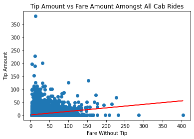

```
The slope of the regression line is 0.14
The correlation coefficient for fare amount and tip amount amongst all cab rides is 0.53
```

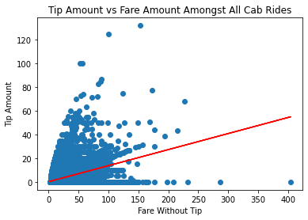

```
The slope of the regression line is 0.14
The correlation coefficient for fare amount and tip amount amongst all cab rides is 0.53
```

```python
# plotting total charge vs. tip amount
x_axis = taxis_cut['total_charge']
y_axis = taxis_cut['tip_amount']

plt.scatter(x_axis, y_axis)

# adding regression line
m, b = np.polyfit(x_axis, y_axis, 1)

plt.plot(x_axis, m*x_axis + b, color='red')
plt.title("Tip Amount vs Fare Amount Amongst All Cab Rides")
plt.xlabel("Fare Without Tip")
plt.ylabel("Tip Amount")
plt.show()

print("The slope of the regression line is {:.2f}".format(m))

# getting correlation coefficient
pearsons = sp.pearsonr(taxis_cut['total_charge'], taxis_cut['tip_amount'])
print("The correlation coefficient for fare amount and tip amount amongst all cab rides is {:.2f}".format(pearsons[0]))

# removing outliers and plotting same data
no_outliers = taxis_cut[taxis_cut['tip_amount'] < 2 * taxis_cut['total_charge']]

plt.close()

x_axis = no_outliers['total_charge']
y_axis = no_outliers['tip_amount']

plt.scatter(x_axis, y_axis)

m, b = np.polyfit(x_axis, y_axis, 1)

plt.plot(x_axis, m*x_axis + b, color='red')
plt.title("Tip Amount vs Fare Amount Amongst All Cab Rides")
plt.xlabel("Fare Without Tip")
plt.ylabel("Tip Amount")
plt.show()

print("The slope of the regression line is {:.2f}".format(m))

pearsons = sp.pearsonr(taxis_cut['total_charge'], taxis_cut['tip_amount'])
print("The correlation coefficient for fare amount and tip amount amongst all cab rides is {:.2f}".format(pearsons[0]))
```

### Initial Results

We create a scatter plot of the data for the fare amount excluding tip, and the tip amount, using Matplotlib. We use numpy, which uses a least squares polynomial fit, to create the line of best fit. We graph these, and use scipy to perform a pearsons correlation test on the data. All of these libraries have incredibly good documentation (linked below), and are made to be easy to use. The reason we perform the function to create a line of best fit is to gain an understanding into the average tip based on the amount spent on the cab fare. A pearsons correlation test tells us if this value actually fits our data, or if the best fit line is just a random line that happens to be the best fit for the data, implying that there is no real best fit for the line We then repeat this process excluding the tip outliers.

We initially look at this relationship in the entire dataset. A scatterplot, along with its line of best fit, is shown below. The slope of the line of best fit for the entire dataset is 0.14, meaning that on average, for every \$1 increase in fare charge, the tip amount increased by \\$0.14. This is followed with a correlation test performed in scipy, which calculates a correlation coefficient of 0.53, meaning that the fare amount and tip amount are fairly positively correlated throughout the entire dataset.

#### Documentation for Scatter Plot

https://matplotlib.org/3.5.0/api/_as_gen/matplotlib.pyplot.scatter.html

#### Documentation for Polyfit

https://numpy.org/doc/stable/reference/generated/numpy.polyfit.html

#### Documentation for Pearsons

https://docs.scipy.org/doc/scipy/reference/generated/scipy.stats.pearsonr.html

```python
small_amounts = no_outliers[no_outliers['total_charge'] < 10]
medium_amounts = no_outliers[no_outliers['total_charge'] < 30]
medium_amounts = medium_amounts[medium_amounts['total_charge'] >= 10]
large_amounts = no_outliers[no_outliers['total_charge'] >= 30]
```

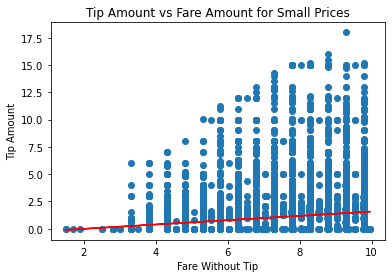

```
The slope of the regression line is 0.20
The correlation coefficient for fare amount and tip amount amongst small fare cab rides is 0.21
```

```python
plt.close()
x_axis = small_amounts['total_charge'].values
y_axis = small_amounts['tip_amount'].values

m, b = np.polyfit(x_axis, y_axis, 1)
plt.plot(x_axis, m*x_axis + b, color='red')

plt.scatter(x_axis, y_axis)
plt.title("Tip Amount vs Fare Amount for Small Prices")
plt.xlabel("Fare Without Tip")
plt.ylabel("Tip Amount")
plt.show()

print("The slope of the regression line is {:.2f}".format(m))
pearsons = sp.pearsonr(small_amounts['total_charge'], small_amounts['tip_amount'])
print("The correlation coefficient for fare amount and tip amount amongst small fare cab rides is {:.2f}".format(pearsons[0]))
```

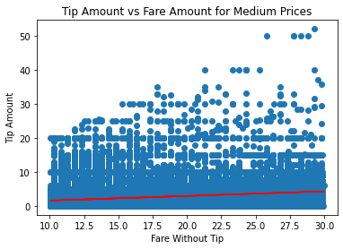

```
The slope of the regression line is 0.14
The correlation coefficient for fare amount and tip amount amongst medium fare cab rides is 0.37
```

```python
plt.close()
x_axis = medium_amounts['total_charge'].values
y_axis = medium_amounts['tip_amount'].values
m, b = np.polyfit(x_axis, y_axis, 1)
plt.plot(x_axis, m*x_axis + b, color='red')

plt.scatter(x_axis, y_axis)
plt.title("Tip Amount vs Fare Amount for Medium Prices")
plt.xlabel("Fare Without Tip")
plt.ylabel("Tip Amount")
plt.show()

print("The slope of the regression line is {:.2f}".format(m))
pearsons = sp.pearsonr(medium_amounts['total_charge'], medium_amounts['tip_amount'])
print("The correlation coefficient for fare amount and tip amount amongst medium fare cab rides is {:.2f}".format(pearsons[0]))
```

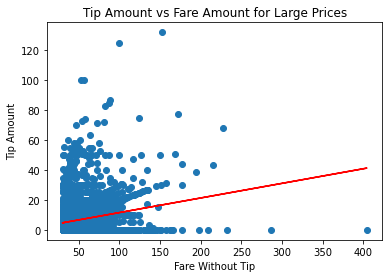

```
The slope of the regression line is 0.10
The correlation coefficient for fare amount and tip amount amongst large fare cab rides is 0.21
```

```python
plt.close()
x_axis = large_amounts['total_charge'].values
y_axis = large_amounts['tip_amount'].values

plt.scatter(x_axis, y_axis)
m, b = np.polyfit(x_axis, y_axis, 1)
plt.plot(x_axis, m*x_axis + b, color='red')

plt.title("Tip Amount vs Fare Amount for Large Prices")
plt.xlabel("Fare Without Tip")
plt.ylabel("Tip Amount")
plt.show()

print("The slope of the regression line is {:.2f}".format(m))
pearsons = sp.pearsonr(large_amounts['total_charge'], large_amounts['tip_amount'])
print("The correlation coefficient for fare amount and tip amount amongst large fare cab rides is {:.2f}".format(pearsons[0]))
```

### Analysis

After performing analysis on all 3 categories, we are left with the results. Firstly, the slope of the line of best fit consistently goes down as the price bracket increases, which matches up with common sense. To increase at the same rate for fares of all prices would cost far more money for higher fare prices than for lower prices. Nobody wants to spend more money than they have to. Similarly, people who have spent less money on the actual fare would be more willing to spend more money on a tip, as they have spent less money overall.

An interesting result is that while the overall correlation coefficient between fare amount and tip is fairly high (0.53), each individual correlation coefficient for a category is fairly low (0.21 for both small and large amounts, and 0.37 for medium amounts). This seems to imply that while there is a correlation in the overall dataset, that correlation is not present in any individual price bracket. This means that we lose our predictive power as we split into individual price brackets.

The analysis of this data gives another question, however. By looking at the graphs, it becomes very apparent that there is a proportion of cab riders who don't tip at all. In all price brackets, the 0 tip amount is layered with many, many riders. This leads us to the question of how much stronger does our correlation become, when we know that someone will tip. That is, given that someone left a tip, how much better is the prediction that we make about how much they will tip. This is the question answered below.

```python
only_tips = no_outliers[no_outliers['tip_amount'] > 0]
only_tips.head()
```

|  | index | tpep_pickup_datetime | tpep_dropoff_datetime | passenger_count | trip_distance | PULocationID | DOLocationID | payment_type | fare_amount | extra | mta_tax | tip_amount | tolls_amount | improvement_surcharge | total_amount | congestion_surcharge | total_charge |
| --- | --- | --- | --- | --- | --- | --- | --- | --- | --- | --- | --- | --- | --- | --- | --- | --- | --- |
| 0 | 0 | 2022-02-01 00:06:58 | 2022-02-01 00:19:24 | 1.0 | 5.40 | 138 | 252 | 1 | 17.0 | 1.75 | 0.5 | 3.90 | 0.0 | 0.3 | 23.45 | 0.0 | 19.55 |
| 4 | 4 | 2022-02-01 00:06:48 | 2022-02-01 00:33:07 | 1.0 | 12.16 | 138 | 125 | 1 | 35.5 | 0.50 | 0.5 | 8.11 | 0.0 | 0.3 | 48.66 | 2.5 | 40.55 |
| 5 | 5 | 2022-02-01 00:57:23 | 2022-02-01 01:07:31 | 2.0 | 2.30 | 140 | 142 | 1 | 10.0 | 3.00 | 0.5 | 2.75 | 0.0 | 0.3 | 16.55 | 2.5 | 13.80 |
| 6 | 6 | 2022-02-01 00:34:17 | 2022-02-01 01:01:32 | 1.0 | 7.50 | 140 | 36 | 1 | 25.0 | 3.00 | 0.5 | 5.00 | 0.0 | 0.3 | 33.80 | 2.5 | 28.80 |
| 7 | 7 | 2022-02-01 00:03:26 | 2022-02-01 00:07:30 | 1.0 | 0.88 | 48 | 68 | 1 | 5.0 | 0.50 | 0.5 | 1.76 | 0.0 | 0.3 | 10.56 | 2.5 | 8.80 |

[figure not shown]

```
The slope of the regression line is 0.19
The correlation coefficient for fare amount and tip amount amongst all cab rides that tipped is 0.80
```

```python
x_axis = only_tips['total_charge']
y_axis = only_tips['tip_amount']

m, b = np.polyfit(x_axis, y_axis, 1)
plt.plot(x_axis, m*x_axis + b, color='red')

plt.scatter(x_axis, y_axis)
plt.title("Tip Amount vs Fare Amount for Small Prices")
plt.xlabel("Fare Without Tip")
plt.ylabel("Tip Amount")
plt.show()

print("The slope of the regression line is {:.2f}".format(m))
pearsons = sp.pearsonr(only_tips['total_charge'], only_tips['tip_amount'])
print("The correlation coefficient for fare amount and tip amount amongst all cab rides that tipped is {:.2f}".format(pearsons[0]))
```

```python
plt.close()
small_amounts = small_amounts[small_amounts['tip_amount'] > 0]
medium_amounts = medium_amounts[medium_amounts['tip_amount'] > 0]
large_amounts = large_amounts[large_amounts['tip_amount'] > 0]
```

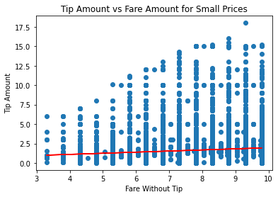

```
The slope of the regression line is 0.14
The correlation coefficient for fare amount and tip amount amongst small fare cab rides that tipped is 0.20
```

```python
plt.close()
x_axis = small_amounts['total_charge'].values
y_axis = small_amounts['tip_amount'].values

m, b = np.polyfit(x_axis, y_axis, 1)
plt.plot(x_axis, m*x_axis + b, color='red')

plt.scatter(x_axis, y_axis)
plt.title("Tip Amount vs Fare Amount for Small Prices")
plt.xlabel("Fare Without Tip")
plt.ylabel("Tip Amount")
plt.show()

print("The slope of the regression line is {:.2f}".format(m))
pearsons = sp.pearsonr(small_amounts['total_charge'], small_amounts['tip_amount'])
print("The correlation coefficient for fare amount and tip amount amongst small fare cab rides that tipped is {:.2f}".format(pearsons[0]))
```

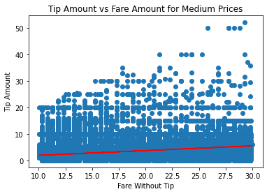

[output not shown]

```python
plt.close()
x_axis = medium_amounts['total_charge'].values
y_axis = medium_amounts['tip_amount'].values

m, b = np.polyfit(x_axis, y_axis, 1)
plt.plot(x_axis, m*x_axis + b, color='red')

plt.scatter(x_axis, y_axis)
plt.title("Tip Amount vs Fare Amount for Medium Prices")
plt.xlabel("Fare Without Tip")
plt.ylabel("Tip Amount")
plt.show()

print("The slope of the regression line is {:.2f}".format(m))
pearsons = sp.pearsonr(medium_amounts['total_charge'], medium_amounts['tip_amount'])
print("The correlation coefficient for fare amount and tip amount amongst small fare cab rides that tipped is {:.2f}".format(pearsons[0]))
```

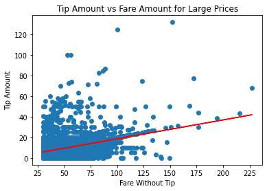

[output not shown]

```python
plt.close()
x_axis = large_amounts['total_charge'].values
y_axis = large_amounts['tip_amount'].values

m, b = np.polyfit(x_axis, y_axis, 1)
plt.plot(x_axis, m*x_axis + b, color='red')

plt.scatter(x_axis, y_axis)
plt.title("Tip Amount vs Fare Amount for Large Prices")
plt.xlabel("Fare Without Tip")
plt.ylabel("Tip Amount")
plt.show()

print("The slope of the regression line is {:.2f}".format(m))
pearsons = sp.pearsonr(large_amounts['total_charge'], large_amounts['tip_amount'])
print("The correlation coefficient for fare amount and tip amount amongst small fare cab rides that tipped is {:.2f}".format(pearsons[0]))
```

### Results

After performing the same analyses on only the data of cab riders that tipped, we are left with the results. The average increase in tip amount based on fare price jumped up moderately (from \$0.14 to \\$0.19), but the correlation coefficient jumped up tremendously, going from 0.53 to 0.80. This means that now that we have removed the people who do not tip at all, there is an incredibly strong correlation between the price of the fair and the amount that is tipped. These results are reflected in both the medium and large price brackets as well. Both had their average increase in tip amount based on fare price increase, and their correlation coefficients increased significantly as well. The small price bracket is different, however. It had both its increase in tip amount based on fare price, and its correlation coefficient, decrease when non-tippers were removed. The most likely explanation for this event is that there is almost no correlation between the tip amount and the fare price for small fares. Riders in this bracket tip whatever they want to, without regard to what they paid for the ride. This could be due to the fact that a "standard" tip, for a ride that cost under \$10, would be incredibly low. Riders who are making the effort to tip their driver aren't going to tip a completely trivial amount, and thus they tip a flat amount instead.

## Miscellaneous Analysis

Matplotlib has an incredibly wide variety of graphs that can be used for analysis, though different situations require different types of graphs. Below are various interesting statistics and analyses that can be gathered from the dataset, and allow us to demonstrate multiple different types of graphs and capabilities throughout.

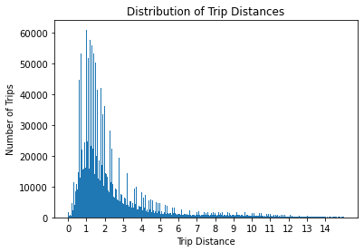

```python
x = taxis_cut[taxis_cut['trip_distance'] <= 15]
plt.hist(x['trip_distance'], bins='auto')
plt.title("Distribution of Trip Distances")
plt.xlabel("Trip Distance")
plt.ylabel("Number of Trips")
plt.xticks(np.arange(0, 15, step=1))
plt.show()
```

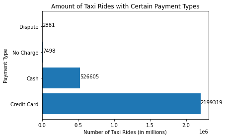

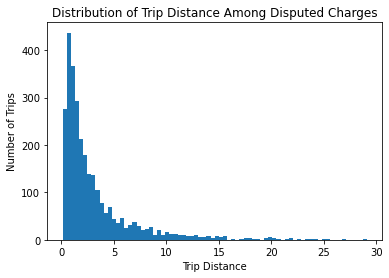

```python
x = ['Credit Card', 'Cash', 'No Charge', 'Dispute']
y = taxis_cut['payment_type'].value_counts()
plt.barh(x, y)
for index, value in enumerate(y):
    plt.text(value, index, str(value))
plt.title("Amount of Taxi Rides with Certain Payment Types")
plt.xlabel("Number of Taxi Rides (in millions)")
plt.ylabel("Payment Type")
plt.show()

plt.close()

x = taxis_cut[taxis_cut['payment_type'] == 4]['trip_distance']
plt.hist(x, bins='auto')
plt.title("Distribution of Trip Distance Among Disputed Charges")
plt.xlabel("Trip Distance")
plt.ylabel("Number of Trips")
plt.show()
```

[output not shown]

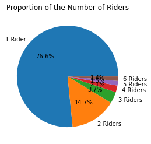

```python
x = ['1 Rider', '2 Riders', '3 Riders', '4 Riders', '5 Riders', '6 Riders']
# x = taxis_cut['passenger_count'].unique()

y = taxis_cut[taxis_cut['passenger_count'] > 0]['passenger_count'].value_counts()

print(len(taxis_cut[taxis_cut['passenger_count'] > 0]))
plt.pie(y, labels=x, autopct='%1.1f%%')
plt.title("Proportion of the Number of Riders")
plt.show()
```

Pictured above are multiple miscellaneous graphs that display some fact about the data. The first graph, titled "Distribution of Trip Distances" is a histogram that plots most of the trip distances amongst the entire dataset. Again, for ease of display, high trip distances were dropped. This includes any trip that was greater than 15 miles. The number of trips in this category was 23806 which, among a dataset of 2.75 million entries, is neglible. From the graph, it can be seen that the vast majority of trips lie in the approximately 0.5 mile - 2.5 mile range. For travelling around New York City, this makes sense. Anything shorter than this is very easily walkable, and anything longer than this and taking a subway would probably be faster due to the traffic.

The second graph, titled "Amount of Taxi Rides with Certain Payment Types" shows exactly what it says. Among all 2.75 million entries, there are 2.2 million credit card payments, 526,000 cash payments, 7,500 rides with no charge at all, and only 2,900 rides with a dispute on the payment. A dispute in this case means that the rider is disputing the amount charged to them by the taxi. This could be for a variety of reasons, but most likely it is because of extra fees, taxes or tolls charged to the rider. It does not appear to be related to distance, as a histogram of the disputed ride distances looks to be the same as the histogram for all trips.

#### Documentation for Barh

https://matplotlib.org/3.5.0/api/_as_gen/matplotlib.pyplot.hist.html

#### Documentation for Pie Chart

https://matplotlib.org/3.5.0/api/_as_gen/matplotlib.pyplot.pie.html

## Time Analysis

A section of the data that we have not touched on yet is the date and time information. The pandas library has a cool and very useful feature called **DateTime**, (documentation for which is linked below) which stores dates/times as objects that make them easy to manage and compare. For some reason, importing the data did not give us datetime objects, so we can convert it using the *pd.to_datetime()* function. For our analysis, we really only need the strings anyway, and I decided it would be easier to have a separate column for date and time. So, we can convert the information they gave us to datetime objects, then use the *strftime()* function to just extract the date or the time by passing in the format. In addition, I use *day_name()* to get the day of the week as a string and make that a column. I then can drop the columns I no longer need.

#### Documentation for Pandas to_datetime

https://pandas.pydata.org/docs/reference/api/pandas.to_datetime.html

#### Documentation for Datetime Objects in Python

https://docs.python.org/3/library/datetime.html

```python
datetimes = pd.to_datetime(taxis_cut['tpep_pickup_datetime'], format='%Y-%m-%d %H:%M:%S')
taxis_cut['pickup_date'] = datetimes.dt.strftime('%Y-%m-%d')
taxis_cut['pickup_time'] = datetimes.dt.strftime('%H:%M:%S')
taxis_cut['day_of_week'] = datetimes.dt.day_name()
taxis_cut.drop(['tpep_pickup_datetime', 'tpep_dropoff_datetime'], axis=1, inplace=True)
taxis_cut.head()
```

|  | index | passenger_count | trip_distance | PULocationID | DOLocationID | payment_type | fare_amount | extra | mta_tax | tip_amount | tolls_amount | improvement_surcharge | total_amount | congestion_surcharge | total_charge | pickup_date | pickup_time | day_of_week |
| --- | --- | --- | --- | --- | --- | --- | --- | --- | --- | --- | --- | --- | --- | --- | --- | --- | --- | --- |
| 0 | 0 | 1.0 | 5.40 | 138 | 252 | 1 | 17.0 | 1.75 | 0.5 | 3.90 | 0.00 | 0.3 | 23.45 | 0.0 | 19.55 | 2022-02-01 | 00:06:58 | Tuesday |
| 1 | 1 | 1.0 | 6.40 | 138 | 41 | 2 | 21.0 | 1.75 | 0.5 | 0.00 | 6.55 | 0.3 | 30.10 | 0.0 | 30.10 | 2022-02-01 | 00:38:22 | Tuesday |
| 2 | 2 | 1.0 | 12.50 | 138 | 200 | 2 | 35.5 | 1.75 | 0.5 | 0.00 | 6.55 | 0.3 | 44.60 | 0.0 | 44.60 | 2022-02-01 | 00:03:20 | Tuesday |
| 3 | 3 | 1.0 | 9.88 | 239 | 200 | 2 | 28.0 | 0.50 | 0.5 | 0.00 | 3.00 | 0.3 | 34.80 | 2.5 | 34.80 | 2022-02-01 | 00:08:00 | Tuesday |
| 4 | 4 | 1.0 | 12.16 | 138 | 125 | 1 | 35.5 | 0.50 | 0.5 | 8.11 | 0.00 | 0.3 | 48.66 | 2.5 | 40.55 | 2022-02-01 | 00:06:48 | Tuesday |

The first graph we'll make with this time data is simply showing how many taxi rides there were on each day of the week throughout the month of February 2022. I would assume that the weekdays would have more rides than the weekend because people typically work on the weekdays then use Saturday and Sunday to relax. The *value_counts()* function is perfect for this, as it can take a column of data and return how many of each value there is. Since February has 28 days, there are exactly 4 of each day of the week in the month, so we can look at the raw totals and don't even have to take the averages.

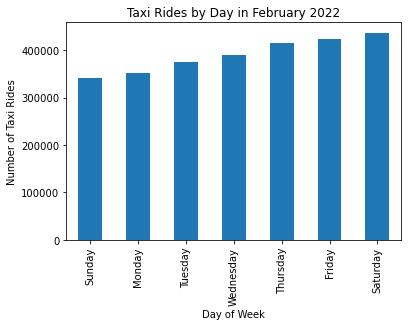

```python
days_data = taxis_cut.day_of_week.value_counts()
days_data = days_data.reindex(index = ['Sunday', 'Monday','Tuesday','Wednesday', 'Thursday', 'Friday', 'Saturday'])
ax = days_data.plot(kind='bar')
ax.set_xlabel('Day of Week')
ax.set_ylabel('Number of Taxi Rides')
ax.title.set_text('Taxi Rides by Day in February 2022')
```

As we can see, my assumption was somewhat correct. Sunday does have the least number of rides, however Saturday has the most, which is interesting. This could be for many reasons. Maybe people like going out on Saturdays and staying in on Sundays. It is also interesting to note that the number of rides per day increases throughout the week. Every day, there are slightly more rides than there were then previous day, then Saturday to Sunday there is a roughly 25% drop in the number of rides. To investigate this further, lets look at every individual day.

To do this, I loop through the dates (1 to 28) and get all of the entries for that date, then append the number of entries to a list. The *shape* function for a DataFrame returns the number of rows and columns as a pair, so by calling *shape[0]*, we get the number of entries.

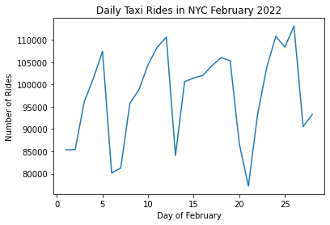

```python
daily_rides = []
for x in range(1,29):
    if x < 10:
        curr_day = '2022-02-0' + str(x)
    else:
        curr_day = '2022-02-' + str(x)

    daily_rides.append(taxis_cut[taxis_cut['pickup_date'] == curr_day].shape[0])

plt.plot(range(1,29), daily_rides)
plt.xlabel('Day of February')
plt.ylabel('Number of Rides')
plt.title('Daily Taxi Rides in NYC February 2022')
```

So what does this plot tell us? It mostly shows us exactly what I said previously. We see an increase during the week, then a sharp decline when we get to Sunday. It is very easy to see when the week starts and ends through this graph.

Now let's look at a couple of individual days. By looking at the graph, I can see the days with the highest number of rides are 2/26 and 2/24. I want to look at a weekend and a weekday to see how the time at which people are riding taxis differs. Since the 24th is a Thursday and the 26th is a Saturday, this is perfect for us. I want to see if people are getting taxis at different times on weekends vs. weekdays. I would predict that on weekdays, people start getting picked up earlier and stop getting picked up later.

The way I did this is ver similar to what I did above. The difference is that I started with only the data for those particular days, then searched for hours within those days by looking at the pickup_time column.

Since we have data for two different days, this is a perfect time to introduce subplots. By calling *plt.subplots(2)*, we can plot two graphs on top of eachother, making them much easier to compare. I put the weekday on top and the weekend on the bottom, and labeled them appropriately.

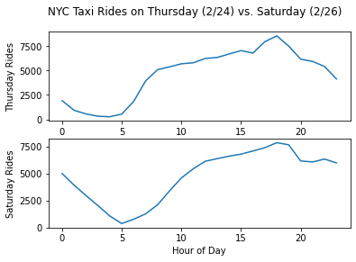

```python
# Getting individual days ready
hourly_rides_weekend = []
hourly_rides_weekday = []
feb_26_data = taxis_cut[taxis_cut['pickup_date'] == '2022-02-26']
feb_24_data = taxis_cut[taxis_cut['pickup_date'] == '2022-02-24']

# Gathering data for these days by hour
for x in range(24):
    if x < 10:
        curr_hour = '0' + str(x)
    else:
        curr_hour = str(x)

    hourly_rides_weekend.append(feb_26_data[feb_26_data['pickup_time'].str.startswith(curr_hour)].shape[0])
    hourly_rides_weekday.append(feb_24_data[feb_24_data['pickup_time'].str.startswith(curr_hour)].shape[0])

# Subplots!
fig, axs = plt.subplots(2)
axs[0].plot(hourly_rides_weekday)
axs[1].plot(hourly_rides_weekend)
fig.suptitle('NYC Taxi Rides on Thursday (2/24) vs. Saturday (2/26)')
axs[1].set_xlabel('Hour of Day')
axs[0].set_ylabel('Thursday Rides')
axs[1].set_ylabel('Saturday Rides')
```

Now I will introduce you to some hypothesis testing. I will be doing two separate tests. The first involves comparing trip distances across different days of the week, to see if any day has a statistically significant difference in the length of the rides people are taking. My thinking is that maybe people are travelling farther on the weekends because they have more free time. To do this, we will need to do an ANOVA test. An ANOVA test will allow us to compare the means of different lists to see if they are equal or not. Our null hypothesis would be that there is no difference in the average trip distance across days of the week. Our alterate is that there is a difference. For this, we can use an alpha level of 0.05

To get the data, I can simply make a list of each day's trip distances by using the day_of_week column that I created earlier. I will then plot the data for one of these days as a histogram to see how it looks.

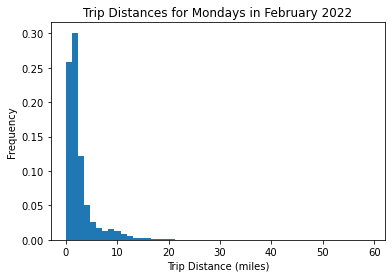

```python
monday_dists = list(taxis_cut[taxis_cut.day_of_week == "Monday"]['trip_distance'])
tuesday_dists = list(taxis_cut[taxis_cut.day_of_week == "Tuesday"]['trip_distance'])
wednesday_dists = list(taxis_cut[taxis_cut.day_of_week == "Wednesday"]['trip_distance'])
thursday_dists = list(taxis_cut[taxis_cut.day_of_week == "Thursday"]['trip_distance'])
friday_dists = list(taxis_cut[taxis_cut.day_of_week == "Friday"]['trip_distance'])
saturday_dists = list(taxis_cut[taxis_cut.day_of_week == "Saturday"]['trip_distance'])
sunday_dists = list(taxis_cut[taxis_cut.day_of_week == "Sunday"]['trip_distance'])
plt.hist(monday_dists, density=True, bins=50)
plt.ylabel('Frequency')
plt.xlabel('Trip Distance (miles)');
plt.title('Trip Distances for Mondays in February 2022')
```

And here we have run into an issue! One of the assumptions for an ANOVA test is that the data must be normal. Clearly, this distribution is not normal. I also plotted every other day just to check and all of them had a similar distribution, however I won't show you all of them here (feel free to do this on your own!). Because there is so much data even for each individual day of the week, I came up with a solution. My idea is to take many samples from our distributions, compute their means, and then use these means as our data. It will still represent the same data, and the Central Limit Theorem tells us that this data should be normal if our sample size is large enough.

So, here I take 1000 samples of size 100 from each day, get the means, and add them to a list. Let's plot one of the days and see how it looks.

[figure not shown]

```python
mon_means = []
tues_means = []
wed_means = []
thurs_means = []
fri_means = []
sat_means = []
sun_means = []
for i in range(1000):
    mon_means.append(s.mean(random.sample(monday_dists, 100)))
    tues_means.append(s.mean(random.sample(tuesday_dists, 100)))
    wed_means.append(s.mean(random.sample(wednesday_dists, 100)))
    thurs_means.append(s.mean(random.sample(thursday_dists, 100)))
    fri_means.append(s.mean(random.sample(friday_dists, 100)))
    sat_means.append(s.mean(random.sample(saturday_dists, 100)))
    sun_means.append(s.mean(random.sample(sunday_dists, 100)))

plt.hist(mon_means, bins=30, density=True)
plt.ylabel('Frequency')
plt.xlabel('Trip Distance (miles)');
plt.title('Sampling Distribution of Sample Mean for Sunday Rides')
```

And now our data looks normal! I checked all other days too just to confirm, I just did not show all of them here. The other 2 assumptions for an ANOVA test are similar variances among data and independence. Obviously, the different days are independent of one another. Variance is a bit trickier, however by looking at the various days, the distributions look roughly the same, so we should be okay to run it.

Scipy gives us a very easy way to run an ANOVA test. The *scipy.stats.f_oneway()* function allows us to pass in our different days and gives us the f-value and p-value that we need.

```python
fvalue, pvalue = sp.f_oneway(mon_means, tues_means, wed_means, thurs_means, fri_means, sat_means, sun_means)
print(fvalue, pvalue)
```

```
272.4265091339292 2.379793892e-314
```

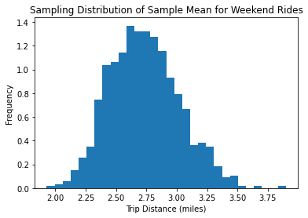

```python
weekday_dists = monday_dists + tuesday_dists + wednesday_dists + thursday_dists + friday_dists
weekend_dists = saturday_dists + sunday_dists
weekday_means = []
weekend_means = []
for i in range(1000):
    weekday_means.append(s.mean(random.sample(weekday_dists, 100)))
    weekend_means.append(s.mean(random.sample(weekend_dists, 100)))

plt.hist(weekend_means, bins=30, density=True)
plt.ylabel('Frequency')
plt.xlabel('Trip Distance (miles)');
plt.title('Sampling Distribution of Sample Mean for Weekend Rides')
```

Now that the data is normalized, let's run the test. Again, the independence assumption is met, so we do not need to worry about that. Scipy also has a *ttest_rel()* function that will do this for us.

```python
sp.ttest_rel(weekday_means, weekend_means)
```

```
Ttest_relResult(statistic=-11.670352136342185, pvalue=1.36216906783426e-29)
```

## 3. Conclusion and Further Research

Throughout this project, we managed to show off many different features of the Python data science pipeline, including data management, graphing/subjective analysis, and hypothesis testing. Since we did not come into it with any overarching questions, there is not much to discuss in the conclusion that we did not already go over in the specific analysis that we did throughout. As you saw, we have linked the documentation for most of the things that we used for our project, so feel free to do further research and develop your own projects. Nothing that we found in our analysis is too shocking. The biggest things would be that people who tip tend to tip relative to the cost of the fare, as expected, and that Saturdays are the busiest days for taxi drivers, at least for our time range of February 2022.

One idea we have to do further research on the topic would be to compare the taxi data with data from Uber over the past few years and see the trends that have developed over time. Even with Uber's dominance in this field, I do not believe that taxis will be going away anytime soon.